# P5_code1_generateResults copy

NOTES (hg19)

- Funseq Trial 1 = TNBC context
- Funseq Trial 2 = pan-cancer context
- Funseq Trial 3 = TNBC context with superenhancers (not used)

NOTES (hg38)

- Ran ALL samples (PCAWG, nikZainal, Staaf, MSK_SNP only alone AND together)
- allSamples = merged before funseq, mergedCohorts = merged after funseq
- funseq score = 0-6 (6 = most "deleterious")
- 0-base vs 1-base:
  - 1-based = GFF, SAM, VCF
    - SNP = chr1:5-5 T/A
    - INS = chr1:3-4 -/TTA
    - DEL = chr1:5-5 T/-
  - 0-based = BED, BAM
    - SNP = chr1:4-5 T/A
    - INS = chr1:3-3 -/TTA
    - DEL = chr1:4-5 T/-
      - places in Funseq/CNCDriver code w/ 0/1-based matters:
      - Variant input should be 0 based, end exclusive (ie chr1:0-100 = spans basepairs 0-99)
      - utils-extractElementMutations.R line ~57 (dat$posStart<-dat$posStart+1, to correct 0-index start position)

```python
%run ~/Documents/Important/modules.ipynb

import pandas as pd
import numpy as np

import matplotlib
from matplotlib import pyplot as plt
from matplotlib.ticker import FormatStrFormatter
from matplotlib_venn import venn2
import seaborn as sns

import scipy.stats as stats
import statsmodels.api as sm
from statsmodels.formula.api import ols


import json
import ast
from ast import literal_eval
import re

pd.set_option('max_columns', None)

# # NOTES
# ssh curie.pbtech
# srun -n1 --pty --partition=panda --mem=50G bash -i
# export PATH=/home/acp4001/ReferenceFiles/linux-amd64-1.1.0:$PATH
# conda activate openssl1.0.0_env
# sq, scancel, sacct -e, sacct --jobs=$SLURM_JOB_ID --format=JobID,MaxRSS
# BRCA_DuxP2gMatrix['gene'], BRCA_DuxP2gMatrix['peak'] = BRCA_DuxP2gMatrix.index.str.rsplit('-',1).str

### Block 00 - 20200714 - Machine/Language: Description
# Run on: (python, R, Cluster)
# In this block
```

# -1 - Building data context

```python
########## RAW FILES ###############

## tcgaSampleInfo = TCGA Sample w/ Cancer type (ie TCGA-OR-A5K8 = breast cancer)	=
##/athena/khuranalab/scratch/dux2001/EX_0189_cellLine_pegenePipeline/source/tcgaSampleInfo.csv
tcgaSampleInfo = pd.read_csv(path+'P5_AOCproject/raw_dux_EX_0161_180608_TCGA_ATAC_StanfordMetadata.txt', sep = '\t')
d(tcgaSampleInfo)

## peak2gene = peak to gene links
##/athena/khuranalab/scratch/dux2001/EX_0177_justPeaks/peak2gene_cutoff0.csv
peak2gene = pd.read_csv(path+'P5_AOCproject/raw_dux_EX_0177_peak2gene_cutoff0.csv', index_col=[0])
d(peak2gene)

p2gCellLines = pd.read_csv(path+'P5_AOCproject/raw_dux_EX_0189_.output._peak2GeneIndMatrix_0.5.csv', index_col=[0])
d(p2gCellLines)

######## OTHER FILES (ie made on elsewhere but necessary for overall code) ############################
## peakLog file, made in 1.1.1 on Cluster
TCGApeaks = pd.read_csv(path+'P5_AOCproject/p5_0.1.1_TCGApeaks.csv', index_col=[0])
d(TCGApeaks)

cellLinePeaks = pd.read_csv(path+'P5_AOCproject/p5_0.1.3_cellLinePeaks.csv', index_col=[0])
d(cellLinePeaks)
```

|  | stanfordUUID | case_id | submitter_id | biospecimen_barcode_side | passedQC | has_WGS | has_WXS | has_GenotypingArray | has_MethylationArray | has_Meth450K | has_Meth27K | has_miRNA-Seq | has_RNA-Seq | cohort | BRCA_scmod2 | BRCA_pam50 | BRCA_ic10 | BRCA_ic11 |
| --- | --- | --- | --- | --- | --- | --- | --- | --- | --- | --- | --- | --- | --- | --- | --- | --- | --- | --- |
| 0 | 000CFD9F-ADDF-4304-9E60-6041549E189C | 2cf68894-168b-458b-af4f-53cad72989a8 | TCGA-A7-A13F | TCGA-A7-A13F-01A-31-A615-42 | Pass | False | True | True | True | True | False | True | True | BRCA | ER+/HER2- High Prolif | LumB | 1.0 | ic1 |
| 1 | 007124EC-1F9B-4FCB-BC6E-DB8C25FD9146 | 1a1cf490-8bd4-4a99-bf3a-34f06435de86 | TCGA-RM-A68W | TCGA-RM-A68W-01A-31-A644-42 | Pass | False | True | True | True | True | False | True | True | PCPG | NaN | NaN | NaN | NaN |

```
(492, 18)
```

|  | TCGA-MP-A4TF | TCGA-MP-A4TE | TCGA-A7-A0CH | TCGA-CU-A3YL | TCGA-IC-A6RE | TCGA-BH-A0DV | TCGA-BH-A0DP | TCGA-Q2-A5QZ | TCGA-IG-A4P3 | TCGA-H4-A2HO | TCGA-85-A4QR | TCGA-VQ-A94O | TCGA-GK-A6C7 | TCGA-B2-A4SR | TCGA-EB-A24C | TCGA-M9-A5M8 | TCGA-BA-A8YP | TCGA-L9-A8F4 | TCGA-AO-A03N | TCGA-MP-A4T7 | TCGA-MP-A4T4 | TCGA-DK-A1AD | TCGA-GL-A9DC | TCGA-CD-A486 | TCGA-85-A512 | TCGA-IG-A3YA | TCGA-LN-A9FQ | TCGA-A2-A0EX | TCGA-A2-A0EY | … |
| --- | --- | --- | --- | --- | --- | --- | --- | --- | --- | --- | --- | --- | --- | --- | --- | --- | --- | --- | --- | --- | --- | --- | --- | --- | --- | --- | --- | --- | --- | --- |
| KTN1-THCA_66795 | 0 | 0 | 0 | 0 | 0 | 0 | 0 | 0 | 0 | 0 | 0 | 0 | 0 | 0 | 0 | 0 | 0 | 0 | 0 | 0 | 0 | 0 | 0 | 0 | 0 | 0 | 0 | 0 | 0 | … |
| ZNF703-ACC_40338 | 1 | 1 | 1 | 1 | 1 | 1 | 1 | 1 | 1 | 1 | 1 | 1 | 1 | 1 | 1 | 1 | 1 | 1 | 1 | 1 | 1 | 1 | 1 | 1 | 1 | 1 | 1 | 1 | 1 | … |

```
(61502, 371)
```

|  | AU-565_S4 | BT-474_S5 | MCF7_S1 | MDA-MB-231_S8 | MDA-MB-361_S2 | SK-BR-3_S3 | T-47D_S6 | ZR-75-1_S7 |
| --- | --- | --- | --- | --- | --- | --- | --- | --- |
| ZNF703-ACC_40338 | 1 | 1 | 1 | 1 | 1 | 1 | 1 | 1 |
| PREB-HNSC_10351 | 1 | 1 | 1 | 1 | 1 | 1 | 1 | 1 |

```
(43302, 8)
```

|  | TCGA-MP-A4TF | TCGA-MP-A4TE | TCGA-A7-A0CH | TCGA-CU-A3YL | TCGA-IC-A6RE | TCGA-BH-A0DV | TCGA-BH-A0DP | TCGA-Q2-A5QZ | TCGA-IG-A4P3 | TCGA-H4-A2HO | TCGA-85-A4QR | TCGA-VQ-A94O | TCGA-GK-A6C7 | TCGA-B2-A4SR | TCGA-EB-A24C | TCGA-M9-A5M8 | TCGA-BA-A8YP | TCGA-L9-A8F4 | TCGA-AO-A03N | TCGA-MP-A4T7 | TCGA-MP-A4T4 | TCGA-DK-A1AD | TCGA-GL-A9DC | TCGA-CD-A486 | TCGA-85-A512 | TCGA-IG-A3YA | TCGA-LN-A9FQ | TCGA-A2-A0EX | TCGA-A2-A0EY | … |
| --- | --- | --- | --- | --- | --- | --- | --- | --- | --- | --- | --- | --- | --- | --- | --- | --- | --- | --- | --- | --- | --- | --- | --- | --- | --- | --- | --- | --- | --- | --- |
| PCPG_2 | 1 | 0 | 0 | 0 | 0 | 0 | 1 | 0 | 1 | 0 | 1 | 0 | 0 | 1 | 1 | 0 | 1 | 0 | 1 | 1 | 0 | 1 | 1 | 1 | 0 | 1 | 1 | 1 | 1 | … |
| LIHC_2 | 0 | 0 | 0 | 0 | 0 | 0 | 0 | 1 | 0 | 0 | 0 | 0 | 0 | 0 | 0 | 0 | 0 | 0 | 0 | 0 | 0 | 0 | 0 | 0 | 0 | 0 | 0 | 0 | 0 | … |

```
(562709, 371)
```

|  | TCGA-MP-A4TF | TCGA-MP-A4TE | TCGA-A7-A0CH | TCGA-CU-A3YL | TCGA-IC-A6RE | TCGA-BH-A0DV | TCGA-BH-A0DP | TCGA-Q2-A5QZ | TCGA-IG-A4P3 | TCGA-H4-A2HO | TCGA-85-A4QR | TCGA-VQ-A94O | TCGA-GK-A6C7 | TCGA-B2-A4SR | TCGA-EB-A24C | TCGA-M9-A5M8 | TCGA-BA-A8YP | TCGA-L9-A8F4 | TCGA-AO-A03N | TCGA-MP-A4T7 | TCGA-MP-A4T4 | TCGA-DK-A1AD | TCGA-GL-A9DC | TCGA-CD-A486 | TCGA-85-A512 | TCGA-IG-A3YA | TCGA-LN-A9FQ | TCGA-A2-A0EX | TCGA-A2-A0EY | … |
| --- | --- | --- | --- | --- | --- | --- | --- | --- | --- | --- | --- | --- | --- | --- | --- | --- | --- | --- | --- | --- | --- | --- | --- | --- | --- | --- | --- | --- | --- | --- |
| PCPG_2 | 1 | 0 | 0 | 0 | 0 | 0 | 1 | 0 | 1 | 0 | 1 | 0 | 0 | 1 | 1 | 0 | 1 | 0 | 1 | 1 | 0 | 1 | 1 | 1 | 0 | 1 | 1 | 1 | 1 | … |
| LIHC_2 | 0 | 0 | 0 | 0 | 0 | 0 | 0 | 1 | 0 | 0 | 0 | 0 | 0 | 0 | 0 | 0 | 0 | 0 | 0 | 0 | 0 | 0 | 0 | 0 | 0 | 0 | 0 | 0 | 0 | … |

```
(562709, 379)
```

### 0.1.1 - Making peak file - in Cluster (orig file was 4GB)

```python
# ssh curie.pbtech
# srun -n1 --pty --partition=panda --mem=16G bash -i
# python
# import pandas as pd
# import numpy as np
# peakLog = pd.read_csv('/athena/khuranalab/scratch/dux2001/EX_0168_panCanExpression/selectedPeakLog.csv', index_col='name')

# columns = list(peakLog.columns)
# index = list(peakLog.index)

# tempdf = peakLog #done so i don't have to reload peakLog dataframe in :P

## CUT OFF IS >= -0.1 is a peak (which is what i did below, just kinda opposite, ie <-0.1 is 0)
# tempdf = pd.DataFrame(np.where(tempdf<-0.1, 0, 1), columns = columns, index = index)

# tempdf.to_csv('/athena/khuranalab/scratch/acp4001/P5_AOCproject/P5_0.1.1_TCGApeaks.csv')

# # downloaded and put in P5 folder
```

### 0.1.2 - Making histograms for # samples each Peak is open in (or is linked to a gene in)

```python
## MAKING LIST OF TNBCs (trip neg breast cancers)

# print(tcgaSampleInfo['cancerType'].value_counts()) # <- JUST CHECKING OUT DATA :)

## Filter by: unique submitter_id ("TCGA-A7-A13F", there are some repeats) -> breast cancer samples only (BRCA) -> trip neg breast cancer only ('basal')
### NB, TNBCs = "Basal" based on PAM50 signature which looks at a panal of 50 genes and groups BRCA into LumA vs LumB vs HER2 vs Basal vs Normal
tempdf = tcgaSampleInfo.drop_duplicates(subset='submitter_id') # 492 -> 484 samples
tempdf = tempdf[(tempdf['cohort'] == 'BRCA') & (tempdf['BRCA_pam50'] == 'Basal')] # 484 -> 80 -> 17 samples
d(tempdf)
TNBClist = tempdf['submitter_id'].to_list()
print(len(TNBClist))
```

|  | stanfordUUID | case_id | submitter_id | biospecimen_barcode_side | passedQC | has_WGS | has_WXS | has_GenotypingArray | has_MethylationArray | has_Meth450K | has_Meth27K | has_miRNA-Seq | has_RNA-Seq | cohort | BRCA_scmod2 | BRCA_pam50 | BRCA_ic10 | BRCA_ic11 |
| --- | --- | --- | --- | --- | --- | --- | --- | --- | --- | --- | --- | --- | --- | --- | --- | --- | --- | --- |
| 4 | 01112370-4F6F-4A20-9BE0-7975C3465268 | 8c7e74e0-71ef-49b8-9217-94b8ef740ef9 | TCGA-A7-A13E | TCGA-A7-A13E-01A-31-A615-42 | Pass | False | True | True | True | True | False | True | True | BRCA | ER-/HER2- | Basal | 10.0 | ic10 |
| 56 | 1BD15E25-9CE5-49AB-ADCF-41F857F3468D | 71f97b63-c970-44ee-98c2-e02e663d5a40 | TCGA-AR-A0U4 | TCGA-AR-A0U4-01A-41-A616-42 | Pass | False | False | True | True | True | False | True | True | BRCA | ER-/HER2- | Basal | 10.0 | ic10 |

```
(17, 18)
```

```
17
```

```python
print(TNBClist)
```

```
['TCGA-A7-A13E', 'TCGA-AR-A0U4', 'TCGA-A2-A4RX', 'TCGA-AR-A0TP', 'TCGA-AR-A0U0', 'TCGA-PL-A8LZ', 'TCGA-AO-A12F', 'TCGA-BH-A0E0', 'TCGA-C8-A12K', 'TCGA-AR-A0TU', 'TCGA-A2-A0YJ', 'TCGA-S3-AA0Z', 'TCGA-BH-A0DL', 'TCGA-A2-A0SX', 'TCGA-AO-A124', 'TCGA-C8-A12V', 'TCGA-AO-A0JB']
```

```python
## Filtering samples for those that are TNBC only
TNBC_TCGApeaks = TCGApeaks.loc[:,TCGApeaks.columns.isin(TNBClist)]
TNBC_peak2gene = peak2gene.loc[:,peak2gene.columns.isin(TNBClist)]

## Adding column that counts number of samples that the peak (or peak-gene link) is present in
TNBC_TCGApeaks['count'] = TNBC_TCGApeaks.sum(axis = 'columns')
TNBC_peak2gene['count'] = TNBC_peak2gene.sum(axis = 'columns')

## Dropping peaks that aren't open in any samples
TNBC_TCGApeaks = TNBC_TCGApeaks.loc[TNBC_TCGApeaks['count'] != 0] # 562,709 -> 481,938 unique peaks
TNBC_peak2gene = TNBC_peak2gene.loc[TNBC_peak2gene['count'] != 0] #61,502 -> 44,992 unique peak-gene links

d(TNBC_TCGApeaks) # THIS DF CONTAINS THE OPEN PEAKS IN TNBC SAMPLES
d(TNBC_peak2gene) # THIS DF CONTAINS THE PEAK-GENE LINKS IN TNBC SAMPLES
```

|  | TCGA-S3-AA0Z | TCGA-AR-A0U4 | TCGA-AR-A0U0 | TCGA-AO-A12F | TCGA-C8-A12V | TCGA-C8-A12K | TCGA-BH-A0E0 | TCGA-AR-A0TP | TCGA-AO-A0JB | TCGA-A2-A0YJ | TCGA-AO-A124 | TCGA-A7-A13E | TCGA-BH-A0DL | TCGA-A2-A4RX | TCGA-A2-A0SX | count |
| --- | --- | --- | --- | --- | --- | --- | --- | --- | --- | --- | --- | --- | --- | --- | --- | --- |
| PCPG_2 | 1 | 0 | 0 | 0 | 0 | 0 | 1 | 0 | 1 | 0 | 1 | 1 | 0 | 1 | 1 | 7 |
| TGCT_2 | 1 | 1 | 1 | 0 | 1 | 1 | 1 | 1 | 0 | 1 | 1 | 1 | 1 | 1 | 1 | 13 |

```
(481938, 16)
```

|  | TCGA-S3-AA0Z | TCGA-AR-A0U4 | TCGA-AR-A0U0 | TCGA-AO-A12F | TCGA-C8-A12V | TCGA-C8-A12K | TCGA-BH-A0E0 | TCGA-AR-A0TP | TCGA-AO-A0JB | TCGA-A2-A0YJ | TCGA-AO-A124 | TCGA-A7-A13E | TCGA-BH-A0DL | TCGA-A2-A4RX | TCGA-A2-A0SX | count |
| --- | --- | --- | --- | --- | --- | --- | --- | --- | --- | --- | --- | --- | --- | --- | --- | --- |
| KTN1-THCA_66795 | 0 | 0 | 0 | 0 | 0 | 0 | 0 | 0 | 0 | 0 | 0 | 1 | 0 | 0 | 0 | 1 |
| ZNF703-ACC_40338 | 1 | 1 | 1 | 1 | 1 | 1 | 1 | 1 | 1 | 1 | 1 | 1 | 1 | 1 | 1 | 15 |

```
(44992, 16)
```

```python
## for peak2gene table, some peak2gene links have the same peak (ie peak1-gene1, peak1-gene2) -> for each peak, calculate # of samples w/ that peak linked to at least 1 gene; ie Pt A has p1-g1 link and Pt B has p1-g2 link; that means that p1 has a link in 2 samples

## 1) Split up peak-gene link into peak, gene
TNBC_peak2gene['gene'], TNBC_peak2gene['peak'] = TNBC_peak2gene.index.str.rsplit('-',1).str
# print(len(TNBC_peak2gene['peak'].unique())) #35866 unique peaks that have links

## 2) make an empty df to add counts to
TNBC_p2g_peakCount = pd.DataFrame(index = TNBC_peak2gene['peak'].unique(), columns = ['count'])

## 3) Add in the counts for peaks with only 1 gene link
### 3a) drop all duplicates
temp_df_1peakTo1gene = TNBC_peak2gene.drop_duplicates(subset = 'peak', keep = False)
### 3b) make list of peaks that only are linked to 1 gene
temp_list_1peakTo1gene = temp_df_1peakTo1gene['peak'].to_list()
# print(len(temp_list_1peakTo1gene))
### 3c) for each peak (with only 1 gene), add the count to the new TNBC_p2g_peakCount
for i in temp_list_1peakTo1gene:
    TNBC_p2g_peakCount.loc[i,'count'] = TNBC_peak2gene.loc[(TNBC_peak2gene['peak'] == i),'count'].values[0]
## did sanity check where I took all the peaks that still had NaN (ie weren't filled in b/c theoretically they had more than 1 gene that they regulated) and overlapped it with a list of known duplicatePeaks, it checked out :) 100% overlap, there are 6735 peaks with links to more than 1 gene

d(TNBC_p2g_peakCount)
```

|  | count |
| --- | --- |
| THCA_66795 | 1 |
| ACC_40338 | 15 |

```
(35866, 1)
```

```python
## 2) Deal w/ the peaks w/ links to >1 gene (ie peak1-gene1, peak1-gene2)
TNBC_p2g_duplicatePeaks = TNBC_peak2gene[TNBC_peak2gene.duplicated(subset = 'peak', keep = False)]
duplicatePeakList = list(TNBC_p2g_duplicatePeaks['peak'].unique())
print(len(duplicatePeakList))
for i in duplicatePeakList:
    temp_df = TNBC_p2g_duplicatePeaks[TNBC_p2g_duplicatePeaks['peak'] == i]
    # add a row called "p2gLinksInPatient" that counts the #links in patient
    temp_df.loc['#p2gLinksInPatient'] = temp_df.sum(axis = 'index')
    noPeakCount = (temp_df.loc['#p2gLinksInPatient'] == 0).sum()
    peakCount = 15 - noPeakCount
    TNBC_p2g_peakCount.loc[i,'count'] = peakCount
#did sanity check, there are no NaN values :) and no values over 15 (which is the max number of samples)
d(TNBC_p2g_peakCount)
```

```
6735
```

|  | count |
| --- | --- |
| THCA_66795 | 1 |
| ACC_40338 | 15 |

```
(35866, 1)
```

```
array([[<matplotlib.axes._subplots.AxesSubplot object at 0x7fa606876e50>]],
      dtype=object)
```

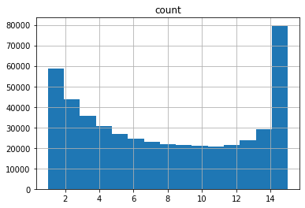

```python
TNBC_TCGApeaks.hist(column = 'count', bins = 15)
```

|  | count |
| --- | --- |
| THCA_66795 | 1 |
| ACC_40338 | 15 |

```
(35866, 1)
```

```
array([[<matplotlib.axes._subplots.AxesSubplot object at 0x7fa68ff76790>]],
      dtype=object)
```

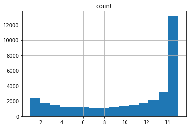

```python
TNBC_p2g_peakCount.to_csv('temp.csv')
TNBC_p2g_peakCount = pd.read_csv('temp.csv', index_col = [0])
d(TNBC_p2g_peakCount)
TNBC_p2g_peakCount.hist(column = 'count', bins = 15)
```

```python
# Just a quick comparison of peaksOpen vs peaksWithLinks
# d(TNBC_TCGApeaks)
# d(TNBC_p2g_peakCount)

temp_TNBCpeaksList = list(TNBC_TCGApeaks.index.unique())
temp_TNBCp2gList = list(TNBC_p2g_peakCount.index.unique())
overlap(temp_TNBCpeaksList,temp_TNBCp2gList)
```

```
len list1:  481938 ; unique:  481938
len list2:  35866 ; unique:  35866
len list1 and list2:  35866
```

```python
# just a quick look at the proportions
print(TNBC_TCGApeaks['count'].value_counts(normalize=True, sort=False))
d(TNBC_TCGApeaks)
```

```
1     0.121646
2     0.090678
3     0.073956
4     0.063597
5     0.055796
6     0.051100
7     0.047396
8     0.044898
9     0.044280
10    0.043802
11    0.043178
12    0.044782
13    0.049224
14    0.060553
15    0.165115
Name: count, dtype: float64
```

|  | TCGA-S3-AA0Z | TCGA-AR-A0U4 | TCGA-AR-A0U0 | TCGA-AO-A12F | TCGA-C8-A12V | TCGA-C8-A12K | TCGA-BH-A0E0 | TCGA-AR-A0TP | TCGA-AO-A0JB | TCGA-A2-A0YJ | TCGA-AO-A124 | TCGA-A7-A13E | TCGA-BH-A0DL | TCGA-A2-A4RX | TCGA-A2-A0SX | count |
| --- | --- | --- | --- | --- | --- | --- | --- | --- | --- | --- | --- | --- | --- | --- | --- | --- |
| PCPG_2 | 1 | 0 | 0 | 0 | 0 | 0 | 1 | 0 | 1 | 0 | 1 | 1 | 0 | 1 | 1 | 7 |
| TGCT_2 | 1 | 1 | 1 | 0 | 1 | 1 | 1 | 1 | 0 | 1 | 1 | 1 | 1 | 1 | 1 | 13 |

```
(481938, 16)
```

```python
## Making/saving files
TNBC_TCGApeaks.to_csv('P5_AOCproject/P5_0.1.2_TNBC_TCGApeaks.csv') # THIS DF CONTAINS THE OPEN PEAKS IN TNBC SAMPLES
TNBC_peak2gene.to_csv('P5_AOCproject/P5_0.1.2_TNBC_peak2gene.csv') # THIS DF CONTAINS THE PEAK-GENE LINKS IN TNBC SAMPLES
```

### 0.1.3 Making Venn diagram: MDA231 vs TNBCs Peaks AND how many new peaks does each sample add?

Making a venn diagram of peaks open in MDA231 vs TNBC. Also doing the same for peaks w/ link

Open peaks 1.1) Find open peaks in MDA231 (done on cluster b/c file is big) 1.2) make a list of open peaks in MDA231 & make a list of open peaks in TNBCs 1.3) Make venn diagram

Peaks w/ link 2.1) filter out rows where MDA-MB-231 has a value of 0 (ie no link) 2.2) format table p2gCellLines to have a column for peaks and another for genes (ie rsplit) 2.3) make a list of unique peaks that have a link predicted for MDA-MB-231 2.4) Do the same for the TNBC dataframe 2.5) Overlap the lists and make venn diagram

```python
####### IMPORT FILES #########
cellLine_peaks = pd.read_csv(path+'P5_AOCproject/p5_0.1.3_cellLinePeaks.csv', index_col=[0])
d(cellLine_peaks)

cellLine_p2g = pd.read_csv(path+'P5_AOCproject/raw_dux_EX_0189_.output._peak2GeneIndMatrix_0.5.csv', index_col=[0])
d(cellLine_p2g)

# THIS DF CONTAINS THE OPEN PEAKS IN TNBC SAMPLES
tnbcTCGA_peaks = pd.read_csv(path+'P5_AOCproject/P5_0.1.2_TNBC_TCGApeaks.csv', index_col = 0)
d(tnbcTCGA_peaks)

# THIS DF CONTAINS THE PEAK-GENE LINKS IN TNBC SAMPLES
tnbcTCGA_p2g = pd.read_csv('P5_AOCproject/P5_0.1.2_TNBC_peak2gene.csv', index_col = 0)
d(tnbcTCGA_p2g)
```

|  | TCGA-MP-A4TF | TCGA-MP-A4TE | TCGA-A7-A0CH | TCGA-CU-A3YL | TCGA-IC-A6RE | TCGA-BH-A0DV | TCGA-BH-A0DP | TCGA-Q2-A5QZ | TCGA-IG-A4P3 | TCGA-H4-A2HO | TCGA-85-A4QR | TCGA-VQ-A94O | TCGA-GK-A6C7 | TCGA-B2-A4SR | TCGA-EB-A24C | TCGA-M9-A5M8 | TCGA-BA-A8YP | TCGA-L9-A8F4 | TCGA-AO-A03N | TCGA-MP-A4T7 | TCGA-MP-A4T4 | TCGA-DK-A1AD | TCGA-GL-A9DC | TCGA-CD-A486 | TCGA-85-A512 | TCGA-IG-A3YA | TCGA-LN-A9FQ | TCGA-A2-A0EX | TCGA-A2-A0EY | … |
| --- | --- | --- | --- | --- | --- | --- | --- | --- | --- | --- | --- | --- | --- | --- | --- | --- | --- | --- | --- | --- | --- | --- | --- | --- | --- | --- | --- | --- | --- | --- |
| PCPG_2 | 1 | 0 | 0 | 0 | 0 | 0 | 1 | 0 | 1 | 0 | 1 | 0 | 0 | 1 | 1 | 0 | 1 | 0 | 1 | 1 | 0 | 1 | 1 | 1 | 0 | 1 | 1 | 1 | 1 | … |
| LIHC_2 | 0 | 0 | 0 | 0 | 0 | 0 | 0 | 1 | 0 | 0 | 0 | 0 | 0 | 0 | 0 | 0 | 0 | 0 | 0 | 0 | 0 | 0 | 0 | 0 | 0 | 0 | 0 | 0 | 0 | … |

```
(562709, 379)
```

|  | AU-565_S4 | BT-474_S5 | MCF7_S1 | MDA-MB-231_S8 | MDA-MB-361_S2 | SK-BR-3_S3 | T-47D_S6 | ZR-75-1_S7 |
| --- | --- | --- | --- | --- | --- | --- | --- | --- |
| ZNF703-ACC_40338 | 1 | 1 | 1 | 1 | 1 | 1 | 1 | 1 |
| PREB-HNSC_10351 | 1 | 1 | 1 | 1 | 1 | 1 | 1 | 1 |

```
(43302, 8)
```

|  | TCGA-S3-AA0Z | TCGA-AR-A0U4 | TCGA-AR-A0U0 | TCGA-AO-A12F | TCGA-C8-A12V | TCGA-C8-A12K | TCGA-BH-A0E0 | TCGA-AR-A0TP | TCGA-AO-A0JB | TCGA-A2-A0YJ | TCGA-AO-A124 | TCGA-A7-A13E | TCGA-BH-A0DL | TCGA-A2-A4RX | TCGA-A2-A0SX | count |
| --- | --- | --- | --- | --- | --- | --- | --- | --- | --- | --- | --- | --- | --- | --- | --- | --- |
| PCPG_2 | 1 | 0 | 0 | 0 | 0 | 0 | 1 | 0 | 1 | 0 | 1 | 1 | 0 | 1 | 1 | 7 |
| TGCT_2 | 1 | 1 | 1 | 0 | 1 | 1 | 1 | 1 | 0 | 1 | 1 | 1 | 1 | 1 | 1 | 13 |

```
(481938, 16)
```

|  | TCGA-S3-AA0Z | TCGA-AR-A0U4 | TCGA-AR-A0U0 | TCGA-AO-A12F | TCGA-C8-A12V | TCGA-C8-A12K | TCGA-BH-A0E0 | TCGA-AR-A0TP | TCGA-AO-A0JB | TCGA-A2-A0YJ | TCGA-AO-A124 | TCGA-A7-A13E | TCGA-BH-A0DL | TCGA-A2-A4RX | TCGA-A2-A0SX | count | gene | peak |
| --- | --- | --- | --- | --- | --- | --- | --- | --- | --- | --- | --- | --- | --- | --- | --- | --- | --- | --- |
| KTN1-THCA_66795 | 0 | 0 | 0 | 0 | 0 | 0 | 0 | 0 | 0 | 0 | 0 | 1 | 0 | 0 | 0 | 1 | KTN1 | THCA_66795 |
| ZNF703-ACC_40338 | 1 | 1 | 1 | 1 | 1 | 1 | 1 | 1 | 1 | 1 | 1 | 1 | 1 | 1 | 1 | 15 | ZNF703 | ACC_40338 |

```
(44992, 18)
```

```python
## Open peaks

###########################################
######## DONE ON CLUSTER ##################

# ssh curie.pbtech
# srun -n1 --pty --partition=panda --mem=16G bash -i
# python
# from scipy import stats
# import pandas as pd
# import numpy as np
# peakCpmAdj = pd.read_csv('/athena/khuranalab/scratch/dux2001/EX_0189_cellLine_pegenePipeline/tmp/peakCpmAdjusted.csv', index_col=[0])

# ## Erica wanted me to check if -0.1 was still the cut off by a) plotting a histogram of MDA-MB-231 values, and b) using gamma distribution to check what the cutoff was
#### for more on gamma distribution => YouTube search "39 - The gamma distribution - an introduction"

###### A ) Plotting histogram ###########
# temp_MB231values = peakCpmAdj['MDA-MB-231_S8'].to_list()
# # print(len(temp_MB231values)) # <- SC
# file = open('/athena/khuranalab/scratch/acp4001/temp_MB231values.txt','w')
# for element in temp_MB231values:
#     file.write(str(element) + '\n')
# file.close()
#### On JUPYTER NOTEBOOK #####
# temp_MDA231_values = pd.read_csv('~/Downloads/temp_MB231values.txt', sep = '\n', header = None)
# d(temp_MDA231_values)
# temp_MDA231_values.hist(bins = 50)

# had min ~-2, max ~6, mode ~-1, was R skewed (ie tail trailing to R)
####################################
##### B) Using Gamm distibution ###########
# fit_alpha, fit_loc, fit_beta=stats.gamma.fit(peakCpmAdj.loc[:,'MDA-MB-231_S8'].values)
# cutoff = stats.gamma.ppf(0.5, fit_alpha, loc=fit_loc, scale=fit_beta)

# print(cutoff) # -0.0552835 <- THIS IS THE CUTOFF GIVEN gamma DISTRIBUTION;

####################################
## Ultimately decided to just use -0.1 as cut off like i had before, rest of code is just like in 1.1.1
# columns = list(peakCpmAdj.columns)
# index = list(peakCpmAdj.index)
# tempdf = peakCpmAdj
# tempdf = pd.DataFrame(np.where(tempdf<-0.1,0,1), columns = columns, index = index)
# tempdf.to_csv('/athena/khuranalab/scratch/acp4001/P5_AOCproject/P5_0.1.3_cellLinePeaks.csv') # imported above as cellLinePeaks
```

|  | TCGA-MP-A4TF | TCGA-MP-A4TE | TCGA-A7-A0CH | TCGA-CU-A3YL | TCGA-IC-A6RE | TCGA-BH-A0DV | TCGA-BH-A0DP | TCGA-Q2-A5QZ | TCGA-IG-A4P3 | TCGA-H4-A2HO | TCGA-85-A4QR | TCGA-VQ-A94O | TCGA-GK-A6C7 | TCGA-B2-A4SR | TCGA-EB-A24C | TCGA-M9-A5M8 | TCGA-BA-A8YP | TCGA-L9-A8F4 | TCGA-AO-A03N | TCGA-MP-A4T7 | TCGA-MP-A4T4 | TCGA-DK-A1AD | TCGA-GL-A9DC | TCGA-CD-A486 | TCGA-85-A512 | TCGA-IG-A3YA | TCGA-LN-A9FQ | TCGA-A2-A0EX | TCGA-A2-A0EY | … |
| --- | --- | --- | --- | --- | --- | --- | --- | --- | --- | --- | --- | --- | --- | --- | --- | --- | --- | --- | --- | --- | --- | --- | --- | --- | --- | --- | --- | --- | --- | --- |
| PCPG_2 | 1 | 0 | 0 | 0 | 0 | 0 | 1 | 0 | 1 | 0 | 1 | 0 | 0 | 1 | 1 | 0 | 1 | 0 | 1 | 1 | 0 | 1 | 1 | 1 | 0 | 1 | 1 | 1 | 1 | … |
| TGCT_2 | 1 | 1 | 1 | 1 | 1 | 1 | 1 | 1 | 1 | 1 | 1 | 1 | 1 | 1 | 1 | 0 | 1 | 1 | 1 | 1 | 1 | 1 | 1 | 1 | 1 | 1 | 1 | 1 | 1 | … |

```
(269204, 379)
```

```
269204
```

|  | TCGA-S3-AA0Z | TCGA-AR-A0U4 | TCGA-AR-A0U0 | TCGA-AO-A12F | TCGA-C8-A12V | TCGA-C8-A12K | TCGA-BH-A0E0 | TCGA-AR-A0TP | TCGA-AO-A0JB | TCGA-A2-A0YJ | TCGA-AO-A124 | TCGA-A7-A13E | TCGA-BH-A0DL | TCGA-A2-A4RX | TCGA-A2-A0SX | count |
| --- | --- | --- | --- | --- | --- | --- | --- | --- | --- | --- | --- | --- | --- | --- | --- | --- |
| PCPG_2 | 1 | 0 | 0 | 0 | 0 | 0 | 1 | 0 | 1 | 0 | 1 | 1 | 0 | 1 | 1 | 7 |
| TGCT_2 | 1 | 1 | 1 | 0 | 1 | 1 | 1 | 1 | 0 | 1 | 1 | 1 | 1 | 1 | 1 | 13 |

```
(481938, 16)
```

```
481938
```

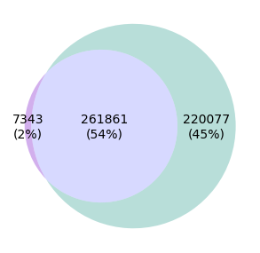

```python
MDA_peaksOpen = cellLine_peaks[cellLine_peaks['MDA-MB-231_S8'] != 0] #562,709 -> 269,204
d(MDA_peaksOpen)
MDA_peaksOpen_list = list(MDA_peaksOpen.index.unique())
print(len(MDA_peaksOpen_list)) # 269,204->269,204; stayed the same as expected b/c all peaks in these tables are unique

TNBC_peaksOpen = tnbcTCGA_peaks[tnbcTCGA_peaks['count'] != 0] #481,938, as expected :).. stayed the same b/c all peaks are unique
d(TNBC_peaksOpen)
TNBC_peaksOpen_list = list(TNBC_peaksOpen.index.unique())
print(len(TNBC_peaksOpen_list)) #481,938 as expected :)

total = len(set(MDA_peaksOpen_list).union(set(TNBC_peaksOpen_list)))

fig1 = plt.figure(figsize=(5,5))
rect = fig1.patch
rect.set_facecolor('white')
v = venn2([set(MDA_peaksOpen_list),set(TNBC_peaksOpen_list)], set_labels=('',''), set_colors=('#9037d4', '#4eada2'), subset_label_formatter=lambda x: str(x) + "\n(" + f"{(x/total):1.0%}" + ")") #last part the "subset_label_formatter=lambda" <- sets it so that percentages are shown too

labels = ['10','01','11']
for i in labels:
    v.get_label_by_id(i).set_fontsize(14)

# d(cellLine_peaks)
# d(cellLine_p2g)
# d(tnbcTCGA_peaks)
# d(tnbcTCGA_p2g)
```